# Avaliação Técnica Analista de Dados - MaxMilhas

Yara Barretto

7/18/2018

# Análises propostas:

### Análise 1: Tempos de Resposta das Buscas

1. Qual é a análise:  
   Analisar o tempo de resposta entre o início e fim da busca e entre fim da busca e recebimento.
2. Motivação da análise:  
   Verificar se as buscas demoram a trazer resultados.  
   Identificar padrões de buscas que se mostram mais efetivos, identificar também quais padrões de buscas são menos efetivos.  
   Identificar pontos onde a busca pode ser melhorada.
3. Como executar:
- Verificar outliers e seu volume, como tempo de respostas negativos ou muito longos.
- Criar novo DataFrame com os dados, excluindo os outliers (caso seu volume seja baixo), para obtermos estatísticas descritivas mais corretas e realistas.
- Realizar um summary na coluna ‘qtd_voos_recebidos’, para obtermos resumo simples dos dados, como Min., Max., 1st Qu. Mediana, Média, 3st Qu. e quantidade de NAs(dados não retornados).
- Verificar quantidade de ‘missing values’, caso a quantidade for muito alta, procurar identificar porque o dado não foi armazenado.
- Plotar gráficos para verificar correlações entre as variáveis disponíveis para análise e o tempo de resposta entre o início e o fim da busca e entre o fim da busca e o recebimento, exemplos:
  - Tempo de resposta x Qtd de voos recebidos
  - Tempo de resposta x Tipo de Voo
  - Tempo de resposta x Número de passageiros
  - Tempo de resposta x Dias da semana
  - Tempo de resposta x Dias da semana + Horário
  - Tempo de resposta x Usuário com id identificado
  - Tempo de resposta x Usuário com id não identificado
- Verificar quais variáveis afetam mais o tempo de resposta da busca.
- Aprofundar a análise em alguns pontos mais relevantes.
- Buscar e propor soluções para a melhoria do tempo de resposta.
- Propor novos dados a serem guardados nas buscas para que possa auxiliar em análises futuras.

### Análise 2: Quantidade de Voos Retornados nas Buscas

1. Qual é a análise:  
   Analisar a quantidade de voos que são retornados nas buscas mais realizadas, analisar também se há padrão de buscas que retornam poucos resultado.
2. Motivação da análise:  
   Verificar se as buscas mais realizadas trazem quantidade considerada como ideal para o cliente que está realizando a pesquisa.  
   Identificar padrões de buscas que retornam mais resultados e padrões de buscas que retornam menos resultados.
3. Como executar:
- Verificar outliers e seu volume, como volume de voos retornados negativos ou > 400.
- Criar novo DataFrame com os dados, excluindo os outliers (caso seu volume seja baixo), para obtermos estatísticas descritivas mais corretas e realistas.
- Realizar um summary na coluna ‘qtd_voos_recebidos’, para obtermos resumo simples dos dados, como Min., Max., 1st Qu. Mediana, Média, 3st Qu. e quantidade de NAs(dados não retornados).
- Verificar quantidade de ‘missing values’, caso a quantidade for muito alta, verificar porque o dado não está sendo armazenado.
- Plotar gráficos para verificar correlação entre as variáveis disponíveis para análise e a quantidade de voos recebidos, exemplos:
  - Qtd de Voos Recebidos x Tipo de Voo
  - Qtd de Voos Recebidos x Classe
  - Qtd de Voos Recebidos x Direção
  - Qtd de Voos Recebidos x Número de passageiros
  - Qtd de Voos Recebidos x Dias da semana
  - Qtd de Voos Recebidos x Dias da semana + Horário
  - Qtd de Voos Recebidos x Usuário com id identificado
  - Qtd de Voos Recebidos x Usuário com id não identificado
  - Qtd de Voos Recebidos x Tempo de resposta
- Verificar quais variáveis mostram afetar o número de voos recebidos.
- Aprofundar a análise nos pontos relevantes.
- Buscar e propor soluções para retornar mais voos onde a quantidade é considerada pequena. Uma solução que pode ser buscada é a adição de novos fornecesores de voos.
- Dentro dessa análise, pode-se verificar as quantidade de melhores preços na MaxMilhas, verificando se tem ou não relação com o número de voos retornados.
- Propor novos dados a serem guardados nas buscas para que possa auxiliar em análises futuras.

### Análise 3: Análise de Perfil do Buscador

1. Qual é a análise:  
   Usar os dados para encontrar um perfil dominante de buscador, e também perfis específicos. Exemplo de Perfil: ‘Voos nacionais, que saem de SP, com duração de 3 a 7 dias, 1 adulto de classe econômica com usuário não identificado’.
2. Motivação da análise:  
   Priorizar correções e demandas das buscas relacionadas aos Perfis de busca dominantes. Criação de Campanhas para Perfis específicos, com a possibilidade de análise clara dos resultados.
3. Como executar:
- Verificar quais dados podem ser usados para montagem do perfil.
- Transformar dados que possíveis de serem transformados em fator, para facilitar a visualização dos dados no R.
- Analisar com summary as variáveis escolhidas e plotar alguns resultados para que possam ser visualizados de forma mais clara.
- Montagem do Perfil com os resultados análisados no passo anterior.
- Montagem de Perfil diferente do dominante geral.
- Propor novos dados a serem guardados nas buscas para que possa auxiliar em análises futuras.

## A análise escolhida para ser realizada é a Análise 3

Preparando os dados para serem analisados:

### Analisando Variáveis

##### Usuários Identificados

Apenas 12% dos usuários que realizam buscam são identificados:

| Buscas com Idusers | Buscas sem Idusers |
| --- | --- |
| *12%* | *88%* |

#### Companhias Aéreas

As companhias aéreas Azul, Gol e Tam retornam volumes semelhantes, já a Avianca retorna menos resultados:

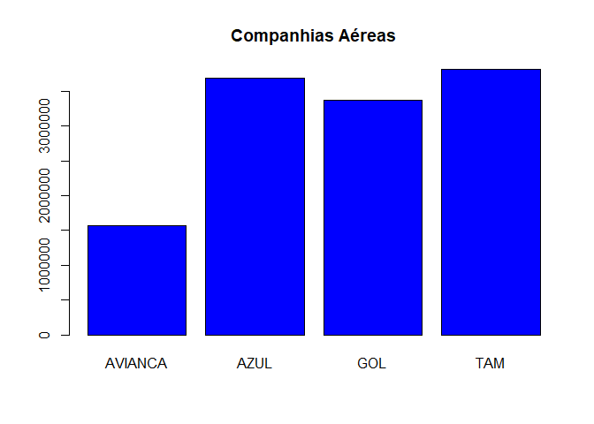

#### Tipos de Voo

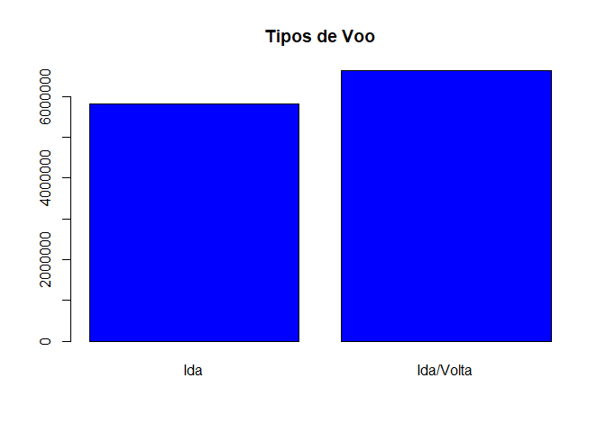

#### Dias Entre Viagens

A média de dias entre viagens é 5, porém viagens muito compridas puxam a média para cima, a mediana nos apresenta um resultado mais relista, no caso a mediana é 1 e 75% das viagens se concentram em até 6 dias.

```
##      Min.   1st Qu.    Median      Mean   3rd Qu.      Max.
##       0.0       0.0       1.0       4.9       6.0 2191460.0
```

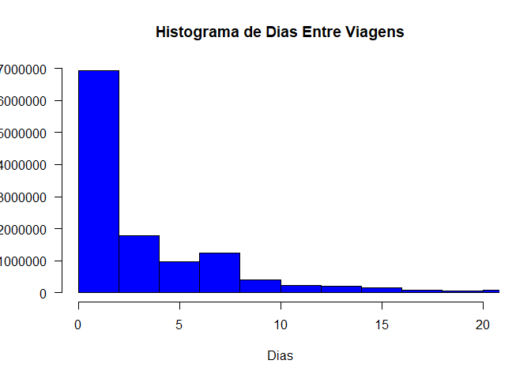

#### Quantidade de Adultos

82% dos clientes buscam passagens para apenas uma pessoa, 15% para duas pessoas e apenas 3% para 3 pessoas ou mais.

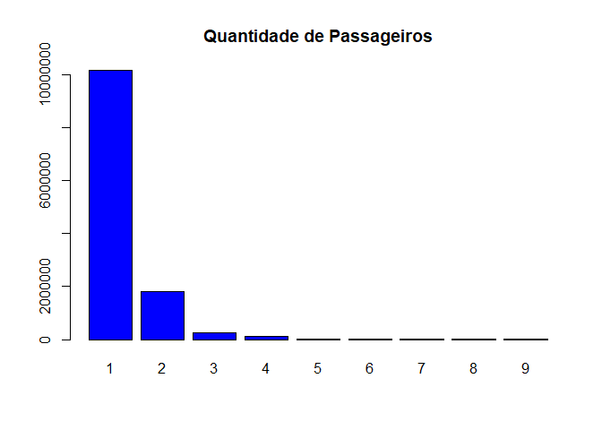

#### Quantidade de Crianças e Bebês

Apenas 6% dos clientes buscam passagens para crianças, sendo que 4% delas buscam passagem para apenas uma criança. Apenas 2% dos clientes buscam passagens incluindo bebês. Podemos ver nos histogramas abaixo que a maioria pesquisa passagem para apenas uma criança ou bebê.

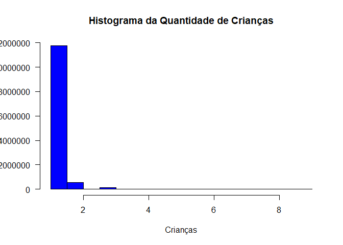

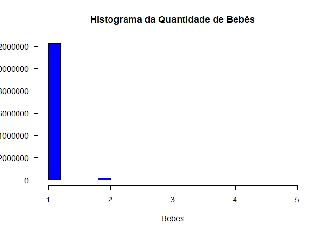

#### Voo Internacional x Voo Nacional

89% dos clientes buscam voos nacionais, 11% buscam voos internacionais.

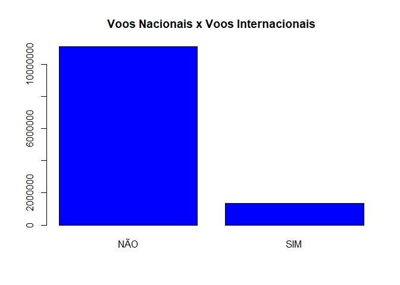

#### Direção dos Voos

89% dos clientes buscam voos nacionais, os outros 11% dividem em 9% saindo do Brasil e 2% voltando para o Brasil.

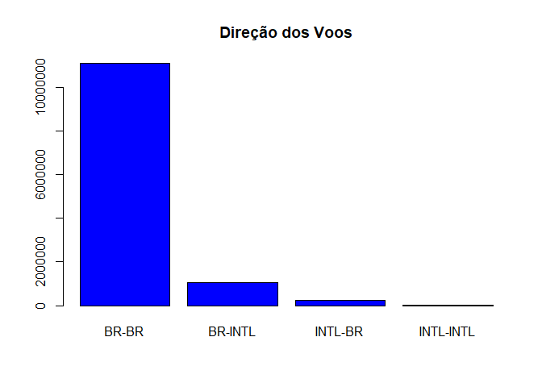

#### Classe

99,7% dos clientes buscam voos de classe econômica.

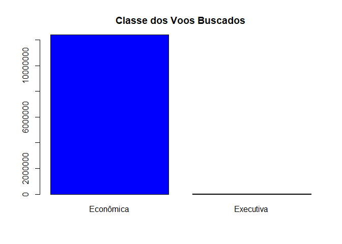

### Perfil Encontrado

Podemos dizer que o Perfil dominante do buscador é:  
Usuários não identificados buscando por passagens de ida e volta nacionais para apenas uma pessoa adulta com duração de 1 dia e para viajar de classe econômica.

### Perfil 2 - Clientes que buscam passagens internacionais

Podemos criar um novo Data Frame contendo somente as buscas internacionais e realizar a mesma análise.

##### Usuários Identificados

Apenas 12% dos usuários que realizam buscam são identificados, mesmo resultado apresentado no perfil dominante geral:

| Buscas com Idusers | Buscas sem Idusers |
| --- | --- |
| *12%* | *88%* |

#### Companhias Aéreas

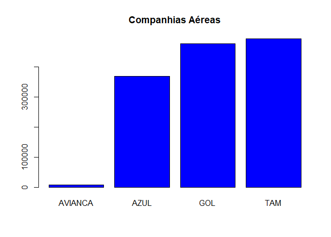

#### Tipos de Voo

Nos tipos de Voos buscados para viagens internacionais, Ida e Volta apresenta volume de 62%:

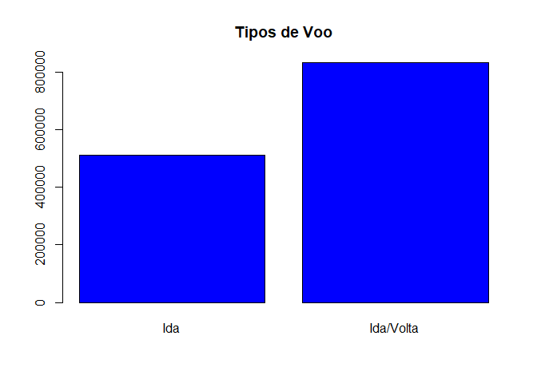

#### Dias Entre Viagens

A média de dias entre viagens internacionais é 11, porém viagens muito compridas puxam a média para cima, a mediana nos apresenta um resultado mais relista, no caso a mediana é 5 e 75% das viagens se concentram em até 11 dias. Temos muitos 0 na base, é um ponto que deve ser verificado.

```
##    Min. 1st Qu.  Median    Mean 3rd Qu.    Max.
##     0.0     0.0     5.0    10.9    11.0   396.0
```

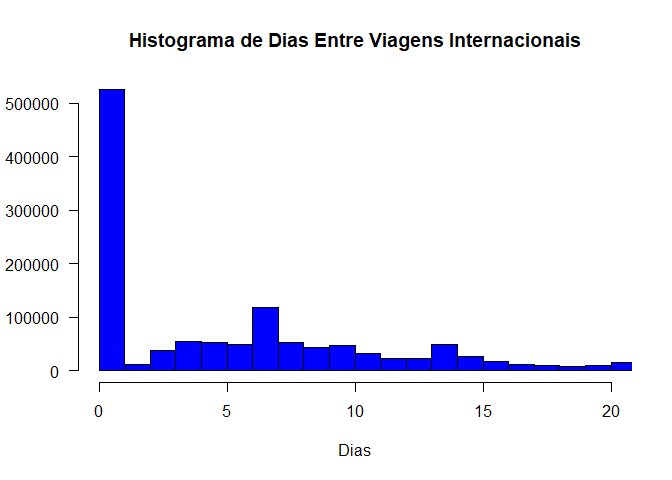

#### Quantidade de Adultos

77% dos clientes que buscam passagens internacionais buscam para apenas uma pessoa, 19% para duas pessoas e apenas 3% para 3 pessoas ou mais.

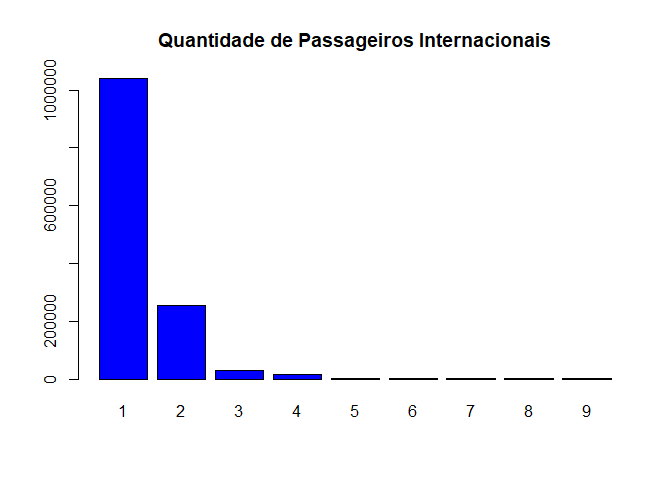

#### Quantidade de Crianças e Bebês

Apenas 5% dos clientes buscam passagens para crianças, sendo que 4% delas buscam passagem para apenas uma criança. Apenas 1% dos clientes buscam passagens incluindo bebês. Podemos ver nos histogramas abaixo que a maioria pesquisa passagem para apenas uma criança ou bebê.

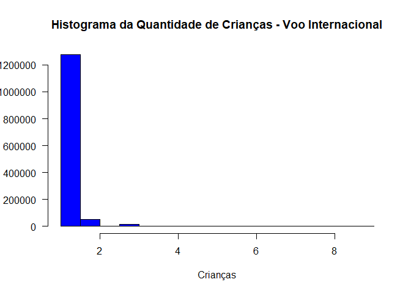

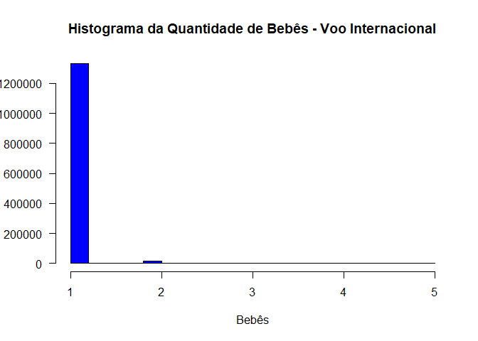

#### Direção dos Voos

79% dos Clientes buscam Voos internacionais partindo do Brasil, 18% partindo de outros países para o Brasil e 3% bucam voos com partidas e destinos internacionais.

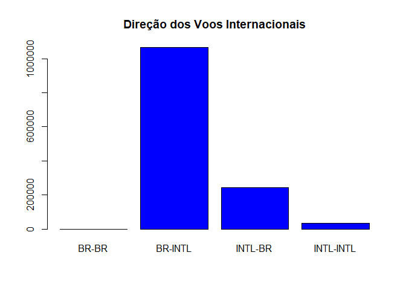

#### Classe

97,3% dos clientes buscam voos de classe econômica.

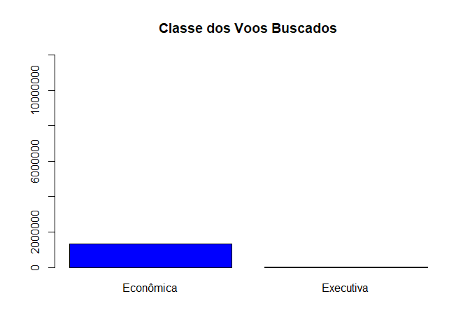

### Perfil Encontrado

Podemos dizer que o Perfil dominante do buscador de passagens internacional é:  
Usuários não identificados buscando por passagens de ida e volta para apenas uma pessoa adulta com duração de média de 11 dias e para viajar de classe econômica.